Feature list · dfaust/soundkonverter Wiki

# Feature list

Jump to bottom [Edit](https://github.com/dfaust/soundkonverter/wiki/Feature-list/_edit) [New Page](https://github.com/dfaust/soundkonverter/wiki/_new)

HessiJames edited this page on Feb 4, 2013 · [5 revisions](https://github.com/dfaust/soundkonverter/wiki/Feature-list/_history)

- Convert audio files between many formats
- Change sample rate and sample size during conversion
- Apply effects like normalize during conversion
- Convert the audio stream from video files to audio files
- Convert multiple files at once
- Calculate Replay Gain for many formats
- Replay Gain tool for calculating and removing Replay Gain tags
- Calculate Replay Gain for multiple files or file stets at once
- Conversion and Replay Gain calculation is very scalable, the conversion of 10000 files or more is not a problem
- Copy tags and covers when converting files (note: for ogg/METADATA_BLOCK_PICTURE, flac and asf/wma files, taglib 1.7 or higher is needed)
- Rip multiple audio CDs at once
- Retrieve audio CD information from CDDB and MusicBrainz
- Easy to use, just choose a file format and a quality level
- Detailed control, if you want to choose the conversion settings in more detail, simply switch to the "detailed" tab
- Manage your preferred conversion options with profiles
- Contextual help, e.g. if you don't know what the speex format is, just click on the "info" button next to it.  
  Or if you want to add a file that isn't supported, soundKonverter will tell you how to enable the format if possible.
- Possibility to configure which backend shall be used for which codec - or let soundKonverter optimize that for you.  
  Every time you install or remove backends soundKonverter will suggest optimizations if possible.
- Possibility to integrate soundKonverter in other applications or scripts by using its command line interface
- Data recovery in case of a crash

For a list of supported backends and formats see [Supported plugins and formats](Supported plugins and formats)

Supported plugins and formats · dfaust/soundkonverter Wiki

# Supported plugins and formats

Jump to bottom [Edit](https://github.com/dfaust/soundkonverter/wiki/Supported-plugins-and-formats/_edit) [New Page](https://github.com/dfaust/soundkonverter/wiki/_new)

Daniel Faust edited this page on May 23, 2013 · [6 revisions](https://github.com/dfaust/soundkonverter/wiki/Supported-plugins-and-formats/_history)

The following plugins are part of soundKonverter. They enable the use of the listed formats through so called backends. Backends are programs doing the actual conversion in the background. In order to use them they must first be installed. See [Installing backends](Installing backends) for more details on this. Since you won't need all backends you can look through the tables to see which backends you really need.  
File formats are printed bold if the plugin in the same row is the preferred one.

### Encoders and decoders

| Plugin | Encode | Decode |
| --- | --- | --- |
| faac | **aac<sup>1</sup>**, **m4a/aac<sup>2</sup>** | **aac<sup>1</sup>**, **m4a/aac<sup>2</sup>** |
| ffmpeg | ogg vorbis, mp3, flac, wma, aac<sup>1</sup>, m4a/aac<sup>2</sup>, m4a/alac<sup>3</sup>, ac3, mp2, amr nb | ogg vorbis, mp3, flac, wma, aac<sup>1</sup>, m4a/aac<sup>2</sup>, m4a/alac<sup>3</sup>, ac3, mp2, sad, als, amr nb, amr wb, ape, speex, mp1, musepack, shorten, tta, wavpack, ra, 3gp, rm, avi, mkv, ogv… |
| flac | **flac** | **flac** |
| lame | **mp3** | mp2, **mp3** |
| libav | ogg vorbis, mp3, flac, wma, aac<sup>1</sup>, m4a/aac<sup>2</sup>, m4a/alac<sup>3</sup>, ac3, mp2, amr nb | ogg vorbis, mp3, flac, wma, aac<sup>1</sup>, m4a/aac<sup>2</sup>, m4a/alac<sup>3</sup>, ac3, mp2, sad, als, amr nb, amr wb, ape, speex, mp1, musepack, shorten, tta, wavpack, ra, 3gp, rm, avi, mkv, ogv… |
| mplayer |  | ogg vorbis, mp3, flac, wma, aac<sup>1</sup>, m4a/aac<sup>2</sup>, m4a/alac<sup>3</sup>, ac3, mp2, sad, als, amr nb, amr wb, ape, speex, mp1, musepack, shorten, tta, wavpack, ra, 3gp, rm, avi, mkv, ogv… |
| neroaac | m4a/aac<sup>2</sup> | m4a/aac<sup>2</sup> |
| timidity |  | midi, mod |
| fluidsynth |  | midi, mod |
| vorbistools | **ogg vorbis** | **ogg vorbis** |
| twolame | mp2 |  |
| musepack | musepack | musepack |
| flake | flac |  |
| mac | ape | ape |
| shorten | shorten | shorten |
| wavpack | wavpack | wavpack |
| ttaenc | tta | tta |
| opustools<sup>4</sup> | opus | opus |
| speex | speex | speex |
| sox<sup>4</sup> | ogg vorbis, mp3, flac, mp2, 8svx, aiff, amr nb, amr wb<sup>5</sup> | ogg vorbis, mp3, flac, mp2, 8svx, aiff, amr nb, amr wb |

### Filters<sup>4</sup>

| Plugin | Effects |
| --- | --- |
| sox | sample rate, sample size, channels, normalize, bass, treble |

### Replay Gain calculators

| Plugin | Formats |
| --- | --- |
| aacgain | m4a/aac<sup>2</sup>, mp3 |
| metaflac | flac |
| mp3gain | mp3 |
| vorbisgain | ogg vorbis |
| wvgain | wavpack |
| mpcgain | musepack |

### CD rippers

| Plugin |
| --- |
| cdparanoia |

1: A file containing an aac stream without a container  
2: An m4a container file with an aac stream; was referred to as "m4a" before version 2.0.0  
3: An m4a container file with an alac stream; was referred to as "alac" before version 2.0.0  
4: Available as of version 2.0.0  
5: There is currently no way to check if sox was compiled with amr wb encoding support so it is always enabled even though it might not work. Please check the log file in case of an error.

Installing backends · dfaust/soundkonverter Wiki

# Installing backends

Jump to bottom [Edit](https://github.com/dfaust/soundkonverter/wiki/Installing-backends/_edit) [New Page](https://github.com/dfaust/soundkonverter/wiki/_new)

Kokos edited this page on Dec 30, 2020 · [8 revisions](https://github.com/dfaust/soundkonverter/wiki/Installing-backends/_history)

soundKonverter is a so called frontend providing an easy to use graphical user interface to convert audio files. It relies on so called backends, programs that can be started in the background to do the actual conversion. So in order to be able to convert files, you need the necessary backends installed. For a list of all supported backends and their respectively supported file formats, have a look at [Supported plugins and formats](https://github.com/dfaust/soundkonverter/wiki/Supported-plugins-and-formats).

### Using the package manager

Some of the backends might be part of your linux distribution, some won't. And this differs between various distributions. So a good start is to check whether the backend you are trying to install is already provided by your distribution.  
All linux distributions have a package manager. Start it and search for the backend you wish to install. Be sure to try different notations if you can't find it straightaway. If you can find it, then install it and you're done (don't forget to restart soundKonverter, though). Otherwise you will have to find a package somewhere else or install it manually.

### Finding additional package repositories

Most linux distributions provide an additional package source where you can find multimedia packages that can't be provided by the distribution directly due to licensing issues. Some examples include:

- openSUSE: [Packman repository](http://en.opensuse.org/Additional_package_repositories#Packman)
- Ubuntu: Repositories universe and multiverse

You should find out whether your distribution provides such a repository because you will find much more packages there useful beyond soundKonverter.

Ubuntu distribution contains following packages, all can be installed by following apt command:

`apt install cdparanoia faac ffmpeg flac flake fluidsynth lame musepack-tools mplayer sox speex timidity twolame vorbisgain wavpack`

For aacgain, libav, mac, mp3gain, musepack, neroaac, opustools, shorten, ttaenc or vorbistools you will most probably need to build them from their sources.

### Installing backends manually

There are some backends you won't find a package for. In order to install them you will need to go to their respective homepage and look for installation instructions:

- aacgain: http://aacgain.altosdesign.com/
- cdparanoia: http://www.xiph.org/paranoia/
- faac: http://flac.sourceforge.net/
- ffmpeg: http://ffmpeg.org/
- flac: http://flac.sourceforge.net/
- flake: http://flake-enc.sourceforge.net/
- fluidsynth: http://sourceforge.net/apps/trac/fluidsynth/
- lame: http://lame.sourceforge.net/
- libav: http://libav.org/
- mac: http://www.monkeysaudio.com/
- metaflac: http://flac.sourceforge.net/
- mp3gain: http://mp3gain.sourceforge.net/
- mpcgain: http://musepack.net/
- mplayer: http://www.mplayerhq.hu/
- musepack: http://musepack.net/
- neroaac: http://www.nero.com/eng/technologies-aac-codec.html, note: You need to enter an email address but it won't be checked.
- opustools: http://opus-codec.org/
- shorten: http://etree.org/shnutils/shorten/
- sox: http://sox.sourceforge.net/
- speex: http://www.speex.org/
- timidity: http://timidity.sourceforge.net/
- ttaenc: http://en.true-audio.com/
- twolame: http://www.twolame.org/
- vorbisgain: http://www.vorbis.com/
- vorbistools: http://www.vorbis.com/
- wavpack: http://www.wavpack.com/
- wvgain: http://www.wavpack.com/

Converting files · dfaust/soundkonverter Wiki

# Converting files

Jump to bottom [Edit](https://github.com/dfaust/soundkonverter/wiki/Converting-files/_edit) [New Page](https://github.com/dfaust/soundkonverter/wiki/_new)

HessiJames edited this page on Dec 2, 2012 · [3 revisions](https://github.com/dfaust/soundkonverter/wiki/Converting-files/_history)

The central part of soundKonverter - both visually and logically - is the file list. It's a list of files that will be worked off once the conversion process is started.  
The logical steps to convert one or more files are:

1. Add the files to the file list
2. Start the conversion

### Add the files to the file list

Basically there are three ways for adding files to the file list. The first one is to use the "Add" button on the lower left of the soundKonverter main window. You can use the arrow on the right to see more options than just "Add files...".

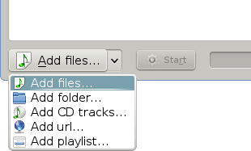

Selecting one of those options will open a new window. In it you will be able to select the files, folders, etc. you wish to add to the file list. After that you will have to choose the conversion options. For more information that see [Choosing good conversion options](Choosing good conversion options).

The second way of adding files to the file list is to use drag'n'drop. You can drag files and folders from your file manager and drop them onto the file list. A widget will fade in that lets you select the conversion options.

The third way is to use the actions menu in Dolphin or another KDE compatible file manager. Select the files you want to add and right-click on them. Choose "Actions" -> "Convert with soundKonverter..." and the files will be added to the soundKonverter file list. Again the widget for selecting the conversion options will fade in. Be aware that the actions menu entry only shows up after soundKonverter has run at least once and only for supported file formats. Also you cannot select multiple files of different formats.

### Start the conversion

Once you have some files in the file list, the "Start" button gets activated. Click on it to start the conversion.

Choosing good conversion options · dfaust/soundkonverter Wiki

# Choosing good conversion options

Jump to bottom [Edit](https://github.com/dfaust/soundkonverter/wiki/Choosing-good-conversion-options/_edit) [New Page](https://github.com/dfaust/soundkonverter/wiki/_new)

Daniel Faust edited this page on May 23, 2013 · [6 revisions](https://github.com/dfaust/soundkonverter/wiki/Choosing-good-conversion-options/_history)

If you want to convert audio files with soundKonverter you will be asked which codec and which options to use. soundKonverter provides two modes to set up conversion options, a "Simple" mode and a "Detailed" mode. You can switch between them by changing the tab in the conversion options window.

### "Simple" mode

[figure not shown]

There are two kinds of codecs, lossy and lossless. Lossy codecs compress the audio data by removing parts of the audio stream that humans don't hear that good. The more data you remove the smaller the file size will be. You can define how much data should be removed by choosing the "Quality" from "Very low" to "Very high". The "Format" selection will then only contain lossy codecs.  
In order to access special codecs like speex or 8svx you need to select "User defined".

**Be aware that by encoding a file with a lossy codec you will always loose quality. This is especially true if you convert from one lossy format to another. (See [generation loss](http://en.wikipedia.org/wiki/Generation_loss).)**

Lossless codecs don't remove data when compressing the audio stream. Therefor a conversion won't lower the quality. The downside is that the file size is big compared to lossy codecs. Choose "Lossless" as "Quality" and then the codec you want to use.

### "Detailed" mode

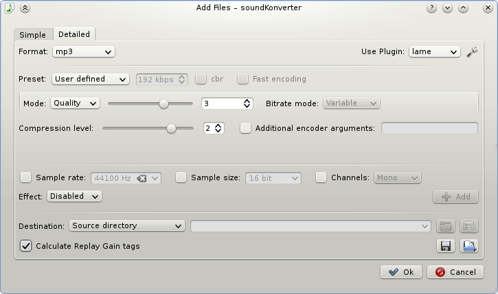

In the "Detailed" tab you can choose the conversion options in greater detail. If you don't know what to do, just use the "Simple" mode.  
Once you have chosen some conversion options you can save them for later as a profile using the save button on the lower right. You can access your saved profiles with either the load button on the lower right in the "Detailed" tab or the "Quality" selection in the "Simple" tab.

### Output directory

If you enter a directory that does not exist, soundKonverter will automatically create it.

Advanced settings · dfaust/soundkonverter Wiki

# Advanced settings

Jump to bottom [Edit](https://github.com/dfaust/soundkonverter/wiki/Advanced-settings/_edit) [New Page](https://github.com/dfaust/soundkonverter/wiki/_new)

HessiJames edited this page on Feb 15, 2013 · [1 revision](https://github.com/dfaust/soundkonverter/wiki/Advanced-settings/_history)

### Setting up back-ends

There are some back-ends that provide additional configuration options. They can be reached via the "Backends" page of the soundKonverter configuration dialog. Use one of the buttons with the tool symbol to open the corresponding configuration dialog.

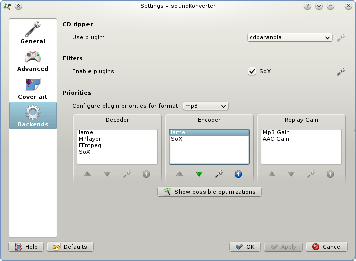

Plugins that can be set up include:

- ffmpeg
- FluidSynth
- lame
- Opus Tools
- sox
- [aacgain](https://github.com/dfaust/soundkonverter/wiki/mp3gain)
- mp3gain